# Insights in International Relations Submitted as Term Project for MATH E-23C

Mohit Negi, Ferran Vega

08 May, 2020

# Introduction

The primary dataset used in this project is Gary King’s “10 Million International Dyadic Events” dataset from Harvard dataverse.

The data available here include almost 10 million individual events, each coded to the exact day they occur or become known. Each event is summarized in the data as “Actor A does something to Actor B”, with Actors A and B recording about 450 countries and other (within-country) actors and “does something to” coded in an ontology of about 200 types of actions. The data are coded by computer from millions of Reuters news reports.

In some topics, we filter this huge dataset to only include “Inter-country” events.

In addition to this, we use several other datasets that are cited appropriately in the relevant topics.

The idea of the project is to utilize the extremely rich dataset to find insights in International Relations. For this, we employ various data analysis techniques.

# Structure of the project

This project aims to apply several concepts taught in class, introduce a variety of new techniques and discover insights by analyzing the data. All the while we try to connect the diverse topics and drive a coherent story.

1. Peer Influence in International Relations.
2. Does providing Aid buy Softpower?
3. The (not-so)Great Escape : Analyzing Political Exile.
4. Minding their own business : Does Geographical Isolation impact development?
5. The World Belligerence Index : Constructing a Global Index using PCA.
6. Fulfilled Project Requirements
7. Conclusion
8. Acknowledgements
9. References

# 1 : Peer Influence in International Relations.

Abstract :

In this topic, we exploit the properties of the Exponential and Weibull probability distributions to see which Inter-country dyadic events might be peer-influenced and which might not.  
The Hazard rate (aka Failure rate) is the conditional probability of “failure” on survival upto a point in time. For a random variable $T$, it is defined as : $\frac{f_T}{1 - F_T}$, where $f_T$ is the PDF and $F_T$ is the CDF of $T$.  
The Exponential distribution (as we’ll see in a bit) has a constant Hazard rate whereas the Weibull with a shape parameter $(\beta) < 1$ has decreasing Hazard rate.  
This property makes the Exponential distribution exhibit “Memoryless-ness” and the Weibull exhibit “Infant-mortality”.  
We use these properties to explore an interesting insight : Some types of events seem to be peer-influenced while some don’t.

First, we discuss our analysis strategy after which we take the theory to data by providing an example of a “peer influenced” event. We then provide a counter-example of an event that does not seem to be peer influenced. Finally, we conclude the topic.

Datasets used : 10 Million International Dyadic Events (10MM_IDE).

### Strategy

We begin by looking at the Poisson process. If the number of events occuring in unit time is a random variable $X \sim Pois(\lambda)$, taking a time interval $[0,\infty)$, the number of events occuring in every subinterval of length $t$ will be a random variable with distribution $Pois(\lambda t)$. Further, the number of events occuring in distinct arbitrary non-overlapping intervals are independent random variables.  
This is a Poisson process.

If we look at the time intervals $T$ between successive occurences in such a Poisson process, they are random variables $T \sim Expo(\lambda)$. This random variable $T$ exhibits the property of “Memoryless-ness” defined as : $P(T > t+x | T = x) = P(T > t)$.  
It is also provable that if $X$ is a positive, continuous random variable that is memoryless, then $\exists \lambda \in \mathbb{R}$ such that $X \sim Expo(\lambda)$.

This is useful to see if the occurence of some event in the world is purely random. Our primary dataset 10MM_IDE includes the date of every event of a certain type between an “Actor” and a “Target”. We filter the data to include only those events where both the parties are of the type “Country”.

The strategy is to determine if the time interval $T$ between successive events of a certain type is exponentially distributed. If it is, it implies that the event occurs purely at random and is not “peer influenced”.

By Peer influence, we mean that the probability of an event occuring is dependent on the occurence of the event before it. If an event occurs between a dyad, it “influences” the probability of the event occuring between other dyads.

It is important to note, however, that if $T$ is not exponentially distributed, it need not imply that the event is peer influenced. For this, we need the Weibull distribution.

The Weibull distribution is a generalization of the Exponential distribution and has the PDF :
$$f_T = \frac{\beta t^{\beta - 1}}{\eta^\beta} e^{-(\frac{t}{\eta})^\beta}$$
and CDF :
$$F_T = 1 - e^{-(\frac{t}{\eta})^\beta}$$
The Hazard rate is :
$$H_T = \frac{f_T}{1 - F_T} = \frac{\beta}{\eta} (\frac{t}{\eta})^{\beta - 1}$$
where $\beta$ is the shape parameter and $\eta$ is the scale parameter.
It is easy to see that when $\beta = 1$, the functions describe the Exponential random variable.

We make the functions in R,

```r
#Weibull PDF function.
weibull_pdf <- function(t,eta,beta){
  beta*(t)^(beta-1)*exp(-1*(t/eta)^beta)/(eta^beta)
}

#Integrating to find the CDF.
weibull_cdf <- Vectorize(function(p,eta,beta){
  integrate(weibull_pdf,lower=10^(-100),upper=p,eta=eta,beta=beta)$value
})

#Hazard rate will be PDF/survival.
hazardrate <- Vectorize(function(x,eta,beta){
  weibull_pdf(x,eta,beta)/(1-weibull_cdf(x,eta,beta))
})
```

It is interesting to note what happens to the $H_T$ as time progresses.
For this, we differentiate $H_T$ w.r.t. $t$.
$$H_T' = \frac{\beta}{\eta^\beta} (\beta - 1) t^{\beta - 2}$$

- When $\beta < 1$, $H_T$ is decreasing. : The probability of the event occuringdecreases over time. Every additional period of survival implies a longer remaining life expectancy (when event occuring is death). This is called the “Lindy Effect”. This property is likened to “Infant Mortality”.
- When $\beta = 1$, $H_T$ is constant. : This is what we call “Memoryless-ness”.
- When $\beta > 1$, $H_T$ is increasing. : The probability of the event occuring increases over time. This is likened to the “wear-and-tear” effect on machine failure events.

Let’s verify this :

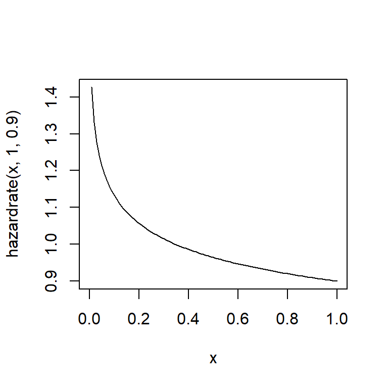

```r
curve(hazardrate(x,1,0.9)) # Weibull with beta < 1 has decreasing hazard rate.
```

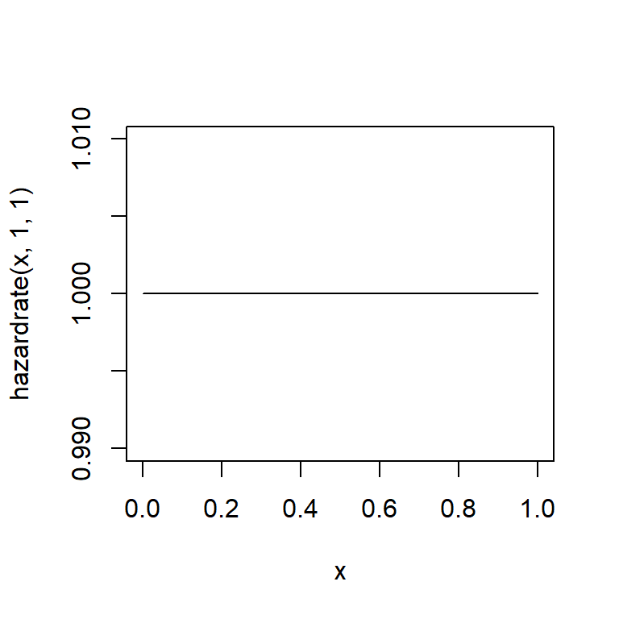

```r
curve(hazardrate(x,1,1)) # Weibull with beta = 1 has constant hazard rate.
```

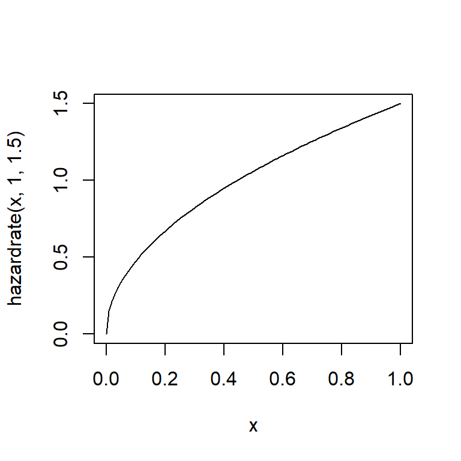

```r
curve(hazardrate(x,1,1.5)) # Weibull with beta > 1 has increasing hazard rate.
```

For our purposes, a Weibull r.v. with $\beta < 1$ can imply a “positive” peer influence. The event encourages more events. When $\beta > 1$, we see “negative” peer influence. The event discourages subsequent events which become more probable as time passes since the last event.

### Taking the theory to data

- *Armed Assistance Requests*

First we look at the events of the type “Ask for armed assistance”. Let’s see if it follows any of our interesting distributions.

We load the data in, do some cleaning and then create a vector that holds the time intervals between subsequent events through the following for loop.

```r
for(i in 1:(nrow(data)-1)){
  if(SrcName[i] != SrcName[i+1] & SrcName[i] != TgtName[i+1]
     & TgtName[i] != TgtName[i+1] & TgtName[i] != SrcName[i+1]){
    j <- difftime(strptime(data$EventDate[i+1], format = "%Y-%m-%d"),
                  strptime(data$EventDate[i], format = "%Y-%m-%d"),units=timeframe)
    vec90 <- c(vec90,j)
  }
}
detach(data)
```

This for loop populates the vec90 vector with date differences of successive events.  
It is computed such that none of the actors(src or tgt) are repeated in successive events.  
This is done to avoid mass-action events like a country asking for armed assisstance from multiple countries at once or multiple countries asking a single country for armed assisstance at once.  
Such events would obviously be peer influenced.  
By doing this, we remove such trivial examples of peer-influence.

We use Likelihood Ratio test for g.o.f of exponential and weibull distributions.

```
    Likelihood ratio test for the Exponential distribution

data:  vec90
S = 2.9502, p-value = 0.085
sample estimates:
[1] 0.165844
```

```
    Test based on the Exponentiated Weibull distribution for the Weibull
    distribution using the MLEs with the Likelihood ratio procedure

data:  vec90
S = 1.0144e-06, p-value = 1
sample estimates:
      eta      beta
5.1813165 0.7685772
```

The weibull fits excellently (pval $> 0.9$) and estimates a shape parameter $\neq 1$. This gives sufficient evidence that armed assisstance requests are NOT purely random and they might be peer influenced. The weibull shape parameter is $0.769$ which tells us there is positive peer influence.

Let’s graph our fitted curves.

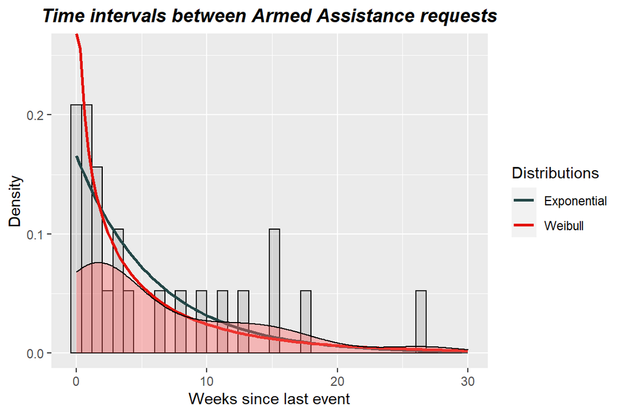

Let’s calculate the Expected number of days between two subsequent armed assistance requests.

```r
integrand1 <- function(t,eta,beta){
  t*(beta*(t)^(beta-1)*exp(-1*(t/eta)^beta)/(eta^beta))
}

exp_days <- function(eta,beta)integrate(integrand1,lower = 10^(-100),upper = Inf,eta=eta,beta=beta)$value

exp_days(w1$estimate[1],w1$estimate[2])
```

```
[1] 6.049117
```

Which tells us that the Expected number of days between two subsequent armed assistance requests is about 6 weeks.

### Taking the theory to data

- *Giving Ultimatums*

Now we look at the events of the type “Give ultimatum”. Let’s see if it follows any of our interesting distributions.

In a similar manner, we generate the vector and conduct a Likelihood Ratio test on it.

```
    Likelihood ratio test for the Exponential distribution

data:  vec90
S = 0.014257, p-value = 0.895
sample estimates:
[1] 0.2006745
```

```
    Test based on the Exponentiated Weibull distribution for the Weibull
    distribution using the MLEs with the Likelihood ratio procedure

data:  vec90
S = 8.1441e-06, p-value = 0.985
sample estimates:
     eta     beta
5.017213 1.016477
```

The exponential fits well and the weibull fits excellently (pval $> 0.95$) and estimates a shape parameter $\approx 1$. This gives strong evidence that giving ultimatums might be purely random events. The weibull shape parameter is $1.02$. We can’t say it is exactly exponential but for such a small data sample, it’s a good approximation.

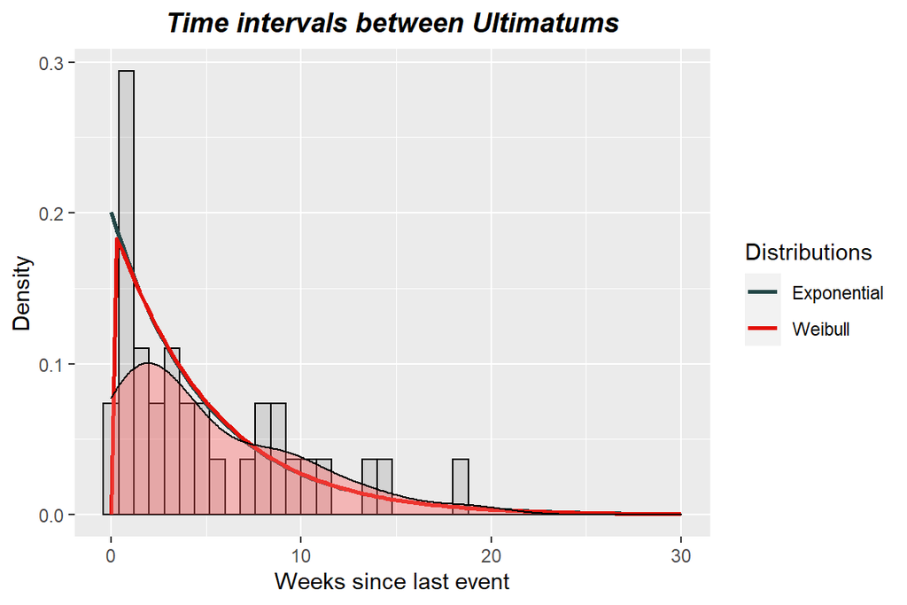

### Taking the theory to data

- *Discussion*

We can draw two conclusions from our analysis. Firstly, we see that the act of asking other countries for military aid might exhibit peer influence.  
The act is defined in such a way that it includes requests of “peacekeeping” forces to international agencies like the UN.  
We filtered the data in such a way that each event was “distinct” than its predecessor in the sense that they didn’t have either party in common.  
A plausible theory might be that during war-time, each belligerant might call upon its allies at approximately the same time.

Secondly, we saw that the act of giving ultimatums might be purely randomly distributed in time. This is reasonable as there doesn’t seem to be any reasons for multiple distinct dyads to influence each other’s actions.

It is also important to note the caveats:

- Due to small sample sizes, the reliability of the results is not perfectly solid.
- We only took data from 1990-1995 as taking the aggregate data (1990-2005) did not yield the same results. This might be due to conditions changing between the long time period that changes $\lambda$. For example, if due to some change in global conditions, the average number of ultimatums in a given week increases after 1995, it would no longer be a Poisson process with a unique $\lambda$. This means if we aggregate pre and post 1995 data, we won’t see the memoryless property even if it exists within the separate time periods.

# 2 : Does providing Aid buy Softpower?

Abstract :

It is widely believed that the provision of Economic Aid by countries to those in need is motivated by more than just good faith. It is common to see countries being accused of “buying favor” through their charitable acts. The most famous example of this might be the “Belt and Road Initiative (BRI)” that was launched by the Chinese government in 2013.  
Many skeptics have raised concerns over the project being a form of “Neo-colonialism”. A favourite example towards this is the Chinese takeover of the Hambantota Port in Sri Lanka for use as a Naval base in the Indian Ocean when the latter was unable to repay debts to China.  
If this phenomenon is indeed true, it may be beneficial to understand if it is effective.  
For this, we analyze the 10MM_IDI dataset, looking at the data on Inter-country dyadic events of the form “Provide Economic Aid” and “Threaten”. We use these variables as proxies for “Aid” and “Softpower”.

The idea is to see if providing Aid to a country significantly impacts the probability of receiving a Threat from it. If this impact turns out to be negative, we can conclude that providing Aid indeed buys Softpower.

In Part I, we conduct some preliminary data analysis to motivate the use of Network Analysis techniques.

In Part II, we actually go about analyzing the the Aid and Threat networks from 1990-2005 through Exponential Random Graph Modelling.

In Part III, we interpret the results and conclude the topic.

Datasets used : 10 Million International Dyadic Events (10MM_IDE).

### I. Preliminary Analysis

Here, we utilize a similar strategy as the last topic wherein we explained how an Exponential distribution can be used to determine if events of a certain type occur purely at random.  
When looking at Network graphs where the different countries are represented as Nodes and dyadic events are represented as the Edges, we can determine the probability of edge formation through Network analysis techniques. This probability $p$ can either be constant across the entire graph or be determined by features such as nodal and edge attributes, neighbouring edges, etc. A graph of the former type is known as an “Erdos-Renyi Random Graph”.

If find an event to occur purely at random, we should expect to see an Erdos-Renyi Graph. If not, we might find the graph to be more complex. In such a graph, ties would not be formed at random but might be dependent on certain nodal and edge attributes. We model such dependencies by using the “Exponential Random Graph Model (ERGM)”.

With this in mind, we try to provide motivations for the use of an ERGM in this section.

We generate the vectors containing time intervals between successive Aid and Threat events using a similar loop as in the last topic. We conduct Likelihood Ratio tests on both these events to check for goodness of fit of an Exponential distribution. We graph these fits.

```
    Likelihood ratio test for the Exponential distribution

data:  aid_totalvec
S = 640.6, p-value < 2.2e-16
sample estimates:
[1] 0.9589257
```

```
    Likelihood ratio test for the Exponential distribution

data:  threat_totalvec
S = 1.6508, p-value = 0.24
sample estimates:
[1] 0.05820758
```

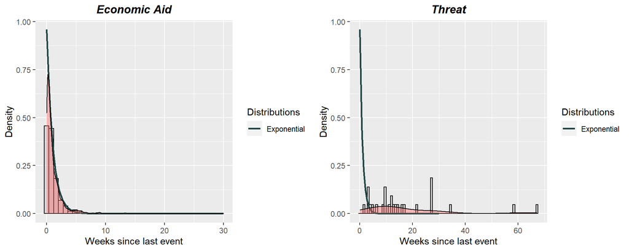

### II. Network Analysis using ERGMs

The Exponential family is a broad family of models for covering many types of data, not just networks. An Exponential Random Graph Model is a model from this family which describes networks.

Formally a random graph $Y$ consists of a set of $n$ nodes and $m$ dyads (edges) ${Y_{ij} : i=1,2,3...n ; j=1,2,3...n}$ where $Y_{ij} = 1$ if the nodes $(i,j)$ are connected and 0 otherwise.

The basic assumption of these models is that the structure in an observed graph $y$ can be explained by any statistics $s(y)$ depending on the observed network and nodal attributes.

The model is defined as :
$$P(Y=y | \theta) = \frac{exp(\theta^Ts(y))}{c(\theta)}$$

where,  
$\theta$ is a vector of model parameters associated with $s(y)$,  
$c(\theta)$ is the normalizing constant to make it a probabiliy measure between $0$ and $1$. It is equal to $\sum_{y \in Y} exp(\theta^T s(y))$

These models represent a probability distribution on each possible network on $n$ nodes and may be directed or undirected.

We can interpret the results of such models in the following way :

We define $Y_{ij}^c$ as the graph we observe before edge $Y_{ij}$ is measured.

$\begin{align*} odds(Y_{ij} = 1) &= \frac{P(Y_{ij}=1|Y_{ij}^c)}{1-P(Y_{ij}=1|Y_{ij}^c)}\\ &= \frac{P(Y_{ij}=1|Y_{ij}^c)}{P(Y_{ij}=0|Y_{ij}^c)}\\ &= \frac{exp(\theta^Ts(Y_{ij}^+))}{exp(\theta^Ts(Y_{ij}^-))}\end{align*}$

Here, $Y_{ij}^+$ is the graph with edge $Y_{ij}$ present and $Y_{ij}^-$ is the graph where its absent. It is important to note that both these graphs are identical $\forall Y_{pq} \in Y \neq Y_{ij}$.

$\begin{align*} odds(Y_{ij} = 1) &= exp(\theta^Ts(Y_{ij}^+) - \theta^Ts(Y_{ij}^-))\\ &= exp(\theta^T[s(Y_{ij}^+) - s(Y_{ij}^-)])\end{align*}$

Here, $s(Y_{ij}^+) - s(Y_{ij}^-)$ is the “change statistic” vector that represents the change in the values of the statistics by adding the edge $Y_{ij}$. Each variable now accounts for the change in counts of network statistics. We notate it as $s(\Delta Y_{ij})$.

$\begin{align*} odds(Y_{ij} = 1) &= exp(\theta^Ts(\Delta Y_{ij}))\\ logodds(Y_{ij} = 1) &= \theta^Ts(\Delta Y_{ij})\\ logit(Y_{ij} = 1) &= \theta_1s_1(\Delta Y_{ij}) + \theta_2s_2(\Delta Y_{ij}) + \theta_3s_3(\Delta Y_{ij}) +.......\theta_ns_n(\Delta Y_{ij}) \end{align*}$

This is the Logit model we solve when we use an ERGM. The statistics can be network features like number of edges, triangles, etc.

Now suppose we choose only “Edges” as the network statistic.  
$\theta_1 s_1(\Delta Y_{ij}) = \theta_1 (1) = \theta_1$  
This is because the change in th edge count by adding edge $Y_{ij}$ is $1$.

Our model thus becomes, $\begin{align*} logodds(Y_{ij} = 1) &= \theta_1\\ odds(Y_{ij}=1) &= exp(\theta_1)\\ \frac{p}{1-p} &= exp(\theta_1)\\ p &= \frac{exp(\theta_1)}{1+exp(\theta_1)} \end{align*}$

This $p$ would be the “Erdos-Renyi” probability of an edge forming randomly. However, the reason we use ERGMs is to model complex networks where $p$ is not constant across the entire network. Just like any other Logit model, we control for these other factors by adding them as covariates in our Logit model.

For example, $logodds(Y_{ij} = 1) = \theta_1Edges + \theta_2GDP_i + \theta_3GDP_j + \theta_4Border$

We cleaned the following datasets to obtain our covariates : 1. GDP per capita 2. Dominant Ethnic Group 3. HDI 4. Borders 5. Alliances : Correlates of War dataset 6. Wars : Correlates of War dataset

We ruled out the following due to issues : 1. Dominant Ethnic Group : Data was available only for a small subset of countries which would pose problems due to the network being sparse and possibility of selection bias. 2. Wars : ERGM models did not converge possibly due to very high collinearity. We suspected the War and alliance data might be too correlated.

We used an extension of the ERGM called the Temporal ERGM (TERGM) to analyze an evolving network where the nodal and edge covariates keep changing over time. We use data from 1990-2005.

For every year, we used a loop to extract all the data and store it into a Network object created using the “btergm” package in R.

```r
  threatnet <- network(threat_adj_1990$adjacency,directed = TRUE,matrix.type = "adjacency")

  network::set.vertex.attribute(threatnet, 'Per Capita Income', as.numeric(node.att.1990$GDP))
  network::set.network.attribute(threatnet,'Alliance', edge.att.1990$Alliance)
  network::set.network.attribute(threatnet,'Border', edge.att.1990$border)
  network::set.network.attribute(threatnet,'Aid', edge.att.1990$Aid)
```

We then run the model with the following specification,

```r
model_fulltime11 <- btergm(netlist ~ edges + mutual()
                          + nodeocov('Per Capita Income')
                          + nodeicov('Per Capita Income')
                          + edgecov('Alliance')
                          + edgecov('Border')
                          + edgecov('Aid'),
                          R = 50)
summary(model_fulltime11)
```

We obtain the results,

```
                                Estimate          2.5%         97.5%
edges                      -9.511498e+00 -10.031063564  -8.932899096
mutual                     -1.385302e+01 -14.191773081 -13.360458628
nodeocov.Per Capita Income -1.333395e-04  -0.005645602   0.003798022
nodeicov.Per Capita Income -2.441944e-03  -0.012074546   0.002026034
edgecov.Alliance           -1.326402e+01 -13.735889016 -12.759769008
edgecov.Border             -1.362840e+01 -13.947717464 -13.212020326
edgecov.Aid                -1.221970e+01 -13.115621735 -10.879325936
```

### III. Discussion

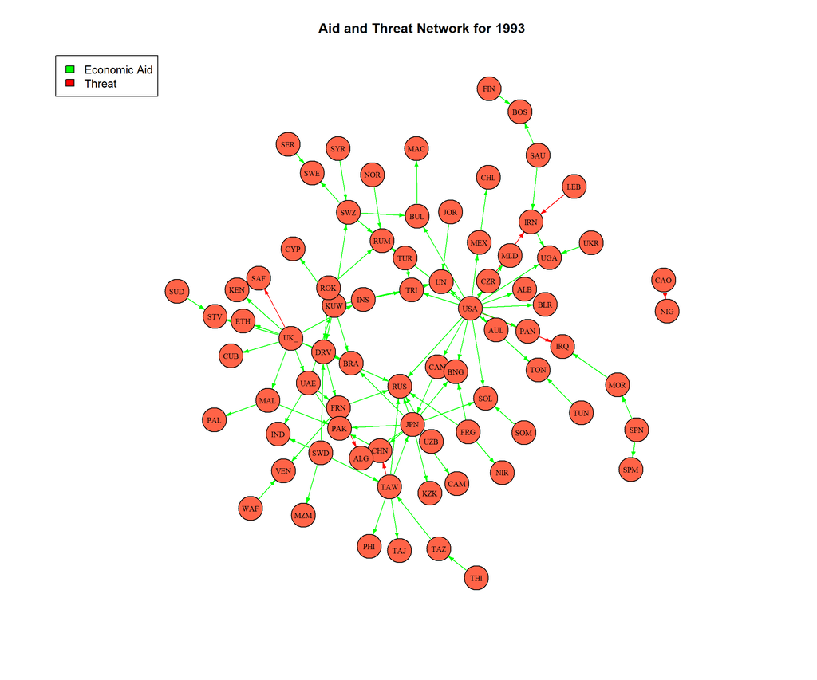

# 3 : The (not-so)Great Escape : Analyzing Political Exile.

Abstract :

In January 1979, after 8 years of despotic rule, Ugandan dictator Idi Amin found himself surrounded by the Tanzanian Army, which had launched a counter-offensive against his forces. As the Ugandan Army retreated, Amin fled into exile to Libya, then ruled by Muammar Gaddafi.  
In this topic, we try to explore what factors might determine where dictators (and politicians in general) flee to when escaping crises. We employ the same Network Analysis framework to analyze the “Political Flight” network constructed from the 10MM_IDI dataset. We try to find the attributes, both nodal and edge-wise, that might have a significant impact on the probability of observing an inter-country political exile edge.

In Part I, we conduct some preliminary data analysis to motivate the use of Network Analysis techniques.

In Part III, we interpret the results and conclude the topic.

Datasets used : 10 Million International Dyadic Events (10MM_IDE).

### I. Preliminary Analysis

We follow the exact procedure as the last topic to see if data on events of the type “Political Flight” follow the Exponential distribution. We’ll use “Asylum” as a short-hand for “Political Flight” in this paper.

```
    Likelihood ratio test for the Exponential distribution

data:  asylum_totalvec
S = 35.012, p-value < 2.2e-16
sample estimates:
[1] 0.1392298
```

We can clearly see that the Exponential does NOT fit Asylum data well (pval $\approx 0$). This gives sufficient evidence that the events are NOT purely random. Edge formation might be dependent on other features.

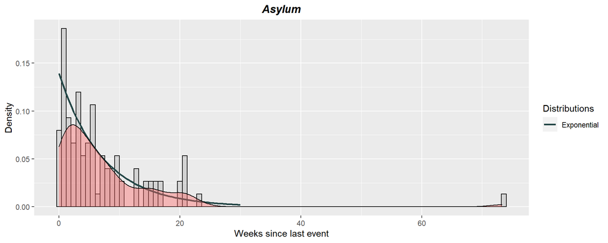

This result motivates us to conduct an ERGM to analyze these networks as they are clearly not Erdos-Renyi Random Graphs.

### II. Network Analysis using ERGMs

We employ the same procedure as the last topic. Here we specify $Y_{ij}$ as a directed edge from i to j representing a politician fleeing from i to j.

We cleaned the following datasets to obtain our covariates : 1. GDP per capita 2. Ethnic Homogeneity 3. HDI 4. Dominant Religious Group 5. Civil conflicts 6. Borders 7. Alliances : Correlates of War dataset 8. Wars : Correlates of War dataset

We ruled out the following due to issues : 1. Ethnic Homogeneity : Data was available only for a small subset of countries which would pose problems due to the network being sparse. 2. Wars : ERGM models did not converge possibly due to very high collinearity. We suspected the War and alliance data might be too correlated.

We use a TERGM like before to model the evolving network.

We then run the model with the following specification,

```r
asylfull6_rel <- btergm(netlist ~ edges + mutual()
                           + nodeocov('Per Capita Income')
                           + nodeicov('Per Capita Income')
                           + nodematch('Religion')
                           + nodeocov('Civil Conflicts')
                           + nodeicov('Civil Conflicts')
                           + nodeocov('HDI')
                           + nodeicov('HDI')
                           + edgecov('Alliance')
                           + edgecov('Border')
                           ,
                           R = 50)
```

We obtain the results,

```
                                Estimate          2.5%        97.5%
edges                      -9.554403e+00 -13.987505139 -7.713146483
mutual                     -1.121583e+01 -13.644752987 -9.149985882
nodeocov.Per Capita Income -2.349755e-04  -0.002711913  0.003555899
nodeicov.Per Capita Income -2.271146e-03  -0.006878858  0.002195479
nodematch.Religion          4.475696e-01   0.108754390  0.951856649
nodeocov.Civil Conflicts    8.606049e-02   0.056021072  0.111564722
nodeicov.Civil Conflicts    7.560511e-02   0.044126878  0.161976805
nodeocov.HDI                3.832585e-01  -1.985858187  2.211232378
nodeicov.HDI                1.012813e+00  -1.494271806  5.073881709
edgecov.Alliance            5.336432e-01  -1.031423457  1.495390309
edgecov.Border              1.659626e-02 -10.526675782  1.613296451
```

### III. Discussion

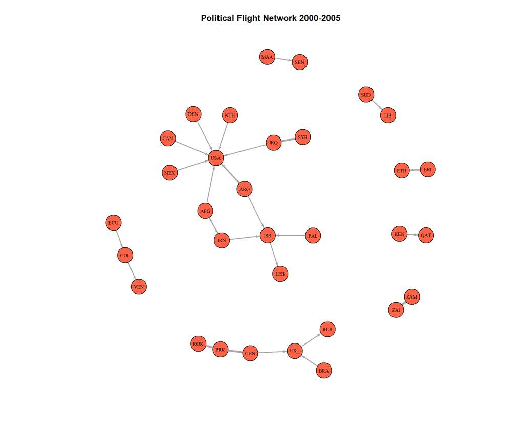

# 4. Minding their own business : Does Geographical Isolation impact development?

Abstract : In this short topic, we analyze HDI and Geographical contiguity data to determine if there is a statistically significant impact of having no borders i.e. being isolated on HDI levels. For this, we make use of the Pearson Chi-squared test. We then use a Permutation test after which we compare the two methods.

Datasets used : HDI Borders

The UNDP classifies each country into one of three development groups: Low human development for HDI scores between 0.0 and 0.5, Medium human development for HDI scores between 0.5 and 0.8. High human development for HDI scores between 0.8 and 1.0. We convert our HDI data to these categorical variables.

We conduct our analysis using the following dataset,

```
  country   HDI No.border HDI_cat
1     AFG 0.387         0     Low
2     ALB 0.687         0  Middle
3     ALG 0.676         0  Middle
4     AND 0.820         0    High
5     ANG 0.428         0     Low
7     ARG 0.775         0  Middle
```

This is the contingency table,

```
         HDI_cat
No.border Low Middle High
        0  39     70   28
        1   3     18    7
```

The Chi square test used in the Contingency table approach requires at least 80% of the cells to have an expected count greater than 5 or else the sum of the cell Chi squares will not have a Chi square distribution. In our case, only 1/6 of the cells have a count lower than 5.

We conduct the Chi-squared test.

```r
ChiSq <-function(Obs,Exp){
  sum((Obs-Exp)^2/Exp)
}

chisq <- ChiSq(Obs,Exp) ; chisq
```

```
[1] 3.865075
```

```r
pvalue <- pchisq(chisq, dfs, lower.tail = FALSE); pvalue
```

```
[1] 0.1447803
```

This pvalue is not small enough for us to reject the null hypothesis of independence. There is over a 14% chance that the observed data pattern could have arisen by chance under the assumption that the null hypothesis of independence is true. We are not comfortable with such a high probability for making a type I error (false positive), and thus conclude that the we cannot reject the null hypothesis of independence in this case.

```r
observed <- Mean.Border - Mean.NoBorder ; observed
```

```
[1] -0.07096872
```

On average, non-isolated countries have HDI 0.0709 points lower than isolated countries.

Now we carry out a permutation test to check whether this difference is significant.

```r
N <- 10000
diff <- numeric(N)

for (i in 1:N){
  samp <- sample(nrow(chisq_data), sum(No.border == 1))
  # obtain random sample of size equal to number of countries without a border in the data
  weightSamp <- mean(HDI[samp]) # mean for random sample
  weightOther <- mean(HDI[-samp]) # mean for complement
  diff[i] <- weightSamp - weightOther # calculate the difference
}
```

Let’s plot a histogram of the results.

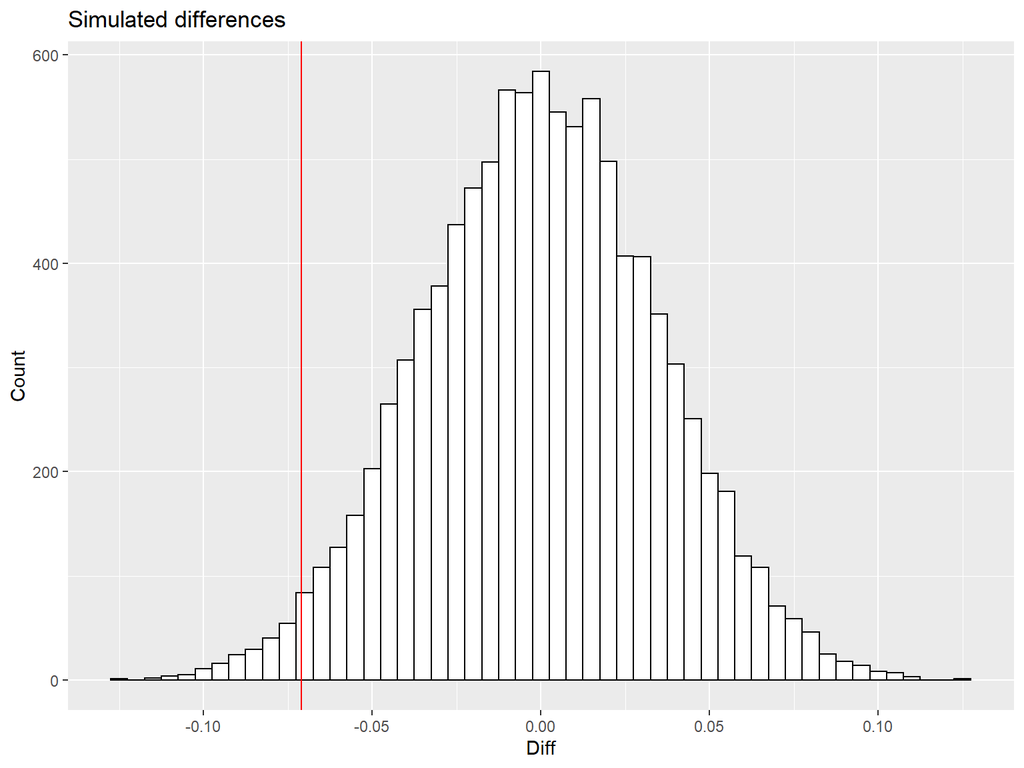

Since we did not try to establish the sign of the difference a priori, we should carry out a two-tailed test.

```r
((sum(diff <= observed)+1)/(N+1))*2
```

```
[1] 0.04259574
```

# 5. The World Belligerence Index : Constructing a Global Index using PCA.

Abstract :

In this topic, we construct a “World Belligerence Index” using Principal Component Analysis. We find that one of our Principal Components captures the variance in “good” and “bad” actions performed by countries. “Bad” actions are mostly composed of belligerent/agressive actions. Using this, we compute Principal Components that help us to identify the belligerent actions, out of which we construct the Index.  
We then regress the Index scores on GDP per capita, HDI, Civil conflicts and a binary variable for presence of a border with another country. These covariates were computed in the many topics covered in this topic.

Datasets used : 10 Million International Dyadic Events (10MM_IDE).

### I. Constructing the World Belligerence Index.

After many attempts, we narrowed down the dataset to just 24 actions. We filtered the actions on the basis of relevance (to the purpose of the index) and removed actions with too low variance.

We convert action counts to percentage of total actions by each country. This is done to avoid capturing variance in total activity amongst the countries.

```r
PCA_data_5 <- select(PCA_data_2, "Countries", "AERI","BREL","CLAS","COLL","COMP_1", "DMOB",
                     "DWAR","ESAN","EAID", "EMAI","EXIL","GRPG","HAID","POLPER", "IMPR","MDEM","NEGO",
                     "PASS","PEXE","RAID", "RALL","SANC","SHEP","THRT_1")
```

```
    Countries AERI        BREL CLAS         COLL      COMP_1        DMOB
1         AFG    0 0.006849315    0 0.0046189376 0.002544529 0.000000000
187       ALB    0 0.000000000    0 0.0000000000 0.013994911 0.000000000
373       ALG    0 0.006849315    0 0.0040415704 0.002544529 0.000000000
559       AND    0 0.000000000    0 0.0000000000 0.000000000 0.000000000
745       ANG    0 0.027397260    0 0.0005773672 0.000000000 0.006430868
931       ANT    0 0.000000000    0 0.0000000000 0.000000000 0.000000000
```

We use Eigenvalue decomposition to compute the Principal components. We create the symmetric covariance matrix and compute its Eigenvectors. These form the orthogonal eigenbasis of out covariance matrix by the Spectral Theorem.

```r
m_5<- nrow(PCA_data_5) ; m_5
A_5 <- PCA_data_5[,2:25] # Select relevant vectors
S_5 <- var(A_5) # Covariance symmetric matrix

#Now we have a symmetric matrix to which the spectral theorem applies.
Eig_5 <- eigen(S_5)
Eig.vals_5 <- Eig_5$values
P_5 <- Eig_5$vectors# This is the change of basis matrix, composed of the eigenvectors
```

These eigenvectors are our Principal Components. By the Spectral Theorem, we know they are orthogonal. We generate a Scree Plot and retain only the ones that explain more than 5% of total variance.

```
## [1] 1
```

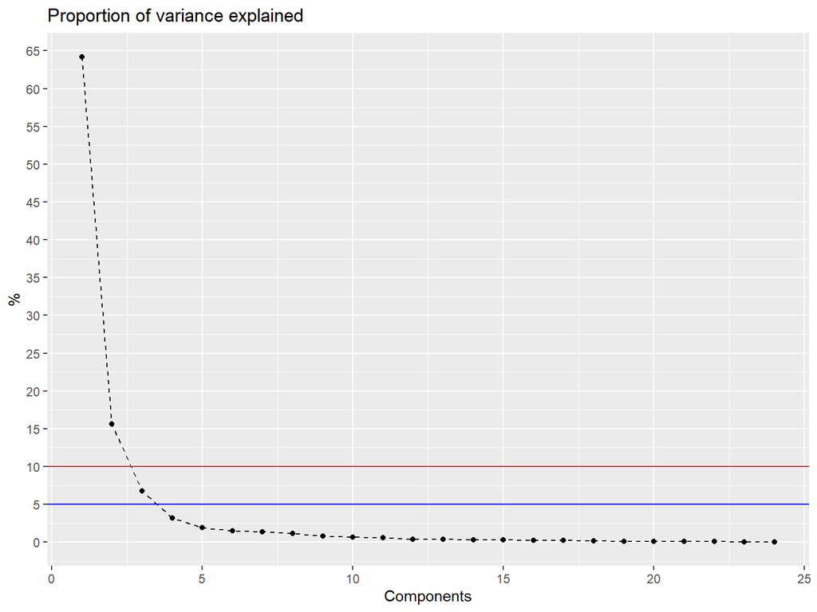

```r
prop.var_5[1]
```

```
[1] 0.6415987
```

```r
prop.var_5[2]
```

```
[1] 0.1559826
```

```r
prop.var_5[3]
```

```
[1] 0.06764636
```

It seems like the first component, the one with the largest eigenvalue, accounts for over 64.1% of the total variance. The second and third account for 15% and 6.7% respectively.

The first component PC1 has negative loadings for each action type and is likely accounting from something related to the overall activity level of countries in the international arena. PC2 and PC3 on the other hand do seem to capture something related to belligerance. We focus on PC2 since this accounts for over 15% of the total variation. On PC2 we see positive loadings on actions that we might normally associate to belligerant and/or aggresive nations. The actions with positive loadings are:

- RAID (Armed actions)
- POLPER (Political flight/arrests) *AERI (Missile attacks)
- CLAS (Armed battle)
- PASS (All uses of non-armed physical force in assaults against people)
- EXIL (Expel)
- PEXE (Small arms attack)
- GRPG (Artillery attack)

Now we use the belligerent actions identified by PC2 to form our Index scores.  
We take the arithmetic mean of the action percentages.

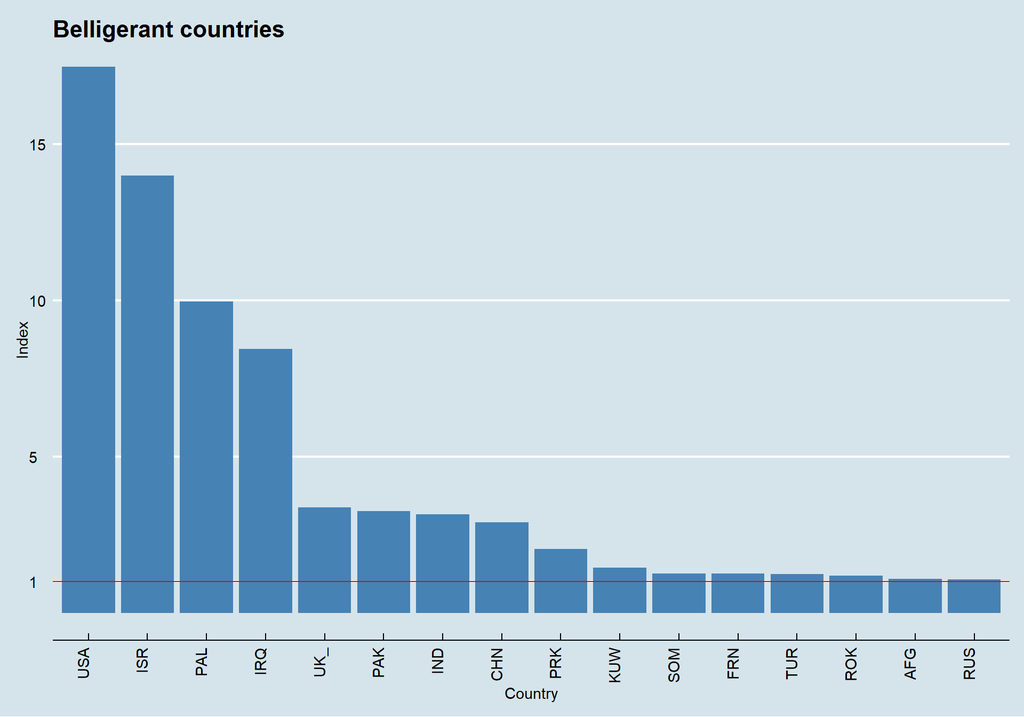

```r
attach(PCA_data_5)
Belligerance.index <- as.data.frame(PCA_data_5$Countries)
Index <- (RAID+POLPER+AERI+CLAS+PASS+EXIL+PEXE+GRPG)/8
Belligerance.index$Index <- Index*100
Belligerance.index <- Belligerance.index[order(-Belligerance.index$Index),]
colnames(Belligerance.index) <- c("country", "Index")
```

### II. Linear Regression

In this section, we use Linear Regression to model how our Index relates to some of the variables we computed and used in all our topics upto now.

We construct the dataframe,

```
  country      Index      GDP CivilWars   HDI No.border
1     AFG 1.08873280 3.637586        50 0.387         0
2     ALB 0.09598991 3.496508         4 0.687         0
3     ALG 0.05605381 3.828641         0 0.676         0
4     AND 0.00000000 4.584967         0 0.820         0
5     ANG 0.09598991 5.257495         0 0.428         0
7     ARG 0.42628969 4.634729         1 0.775         0
```

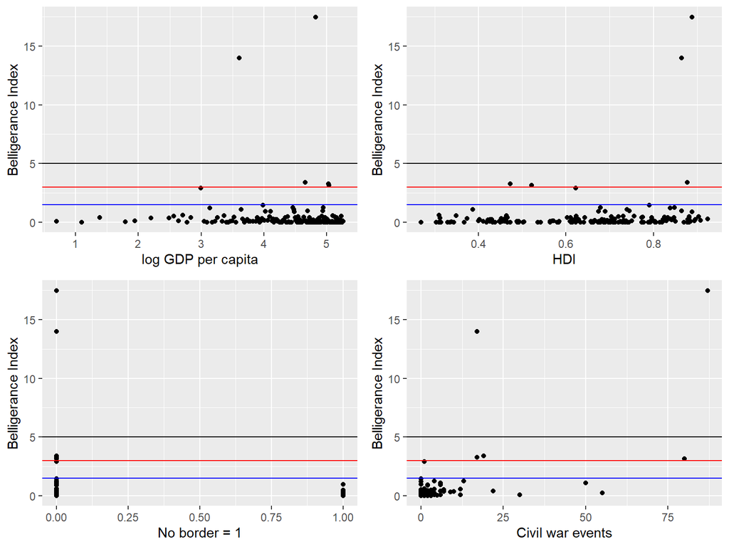

We use the projection matrices approach to conduct Linear Regression.
$$\mathbf{\hat{y}} = A(A^TA)A^T\mathbf{y}$$
where, $\hat{y}$ is the vector of projected y values and A is the matrix with $\mathbf{1}$ and the covariate vectors as its columns.

```r
v1 <- c(rep(1, nrow(Reg_vars)))
A <- cbind(v1, Reg_vars$GDP, Reg_vars$HDI, Reg_vars$CivilWars, Reg_vars$No.border)
coeff <- solve(t(A)%*%A)%*%t(A)%*%Reg_vars$Index
```

We find that the built-in R function lm() returns the same results. We use it to find the t-statistics, f-statistic and R-squared of our model.

```r
reg_model <- lm(Reg_vars$Index ~ Reg_vars$GDP + Reg_vars$HDI + Reg_vars$CivilWars + Reg_vars$No.border)
```

```
=========================================================
                                  Dependent variable:
                              ---------------------------
                                  Belligerance Index
---------------------------------------------------------
Log GDP per cap.                        -0.027
                                        (0.124)

Human Development Index (HDI)          2.353***
                                        (0.647)

Civil war                              0.098***
                                        (0.010)

Lacking border                          -0.323
                                        (0.291)

Constant                                -1.233*
                                        (0.686)

---------------------------------------------------------
Observations                              165
R2                                       0.421
Adjusted R2                              0.407
Residual Std. Error                1.380 (df = 160)
F Statistic                     29.143*** (df = 4; 160)
=========================================================
Note:                         *p<0.1; **p<0.05; ***p<0.01
```

The results suggest that HDI and the occurrence of civil wars lead to increases in the level of belligerance shown by countries as measured by our index. However, given suspicion (motivated by the initial scatterplots of the dependent variable with each individual regressor) that a linear model might not be appropriate for this analysis, we advise not to read too much into these.

# 6. Fulfilled Project Requirements :

**Required dataset standards :**

- A dataframe. (Many)
- At least two categorical or logical columns. (Topic 4)
- At least two numeric columns. (Topic 3)
- At least 20 rows, preferably more, but real-world data may be limited. (10 million rows!, although we reduce it.)

**Required graphical displays :**

- A barplot. (Topic 5)
- A histogram. (Topic 1,2,3)
- A probability density graph overlaid on a histogram. (Topic 1,2,3)
- A contingency table. (Topic 4)

**Required analysis :**

- A permutation test. (Topic 4)
- A p-value or other statistic based on a distribution function. (Topic 1)
- Analysis of a contingency table. (Topic 4)
- Comparison of analysis by classical methods (chi-square, CLT) and simulation methods. (Topic 4)

**Required submission uploads :**

- A .csv file with the dataset (Many)
- A long, well-commented script that loads the dataset, explores it, and does all the analysis.
- A shorter .Rmd with compiled .pdf or .html file that presents highlights in ten minutes.
- A one-page handout that explains the dataset and summarizes the analysis.

**Additional points for creativity or complexity :**

- A data set with lots of columns, allowing comparison of many different variables. (Many variables used in the entire project.)
- A data set that is so large that it can be used as a population from which samples are taken. (10 million observations in original dataset.)
- A graphical display that is different from those in the textbook or in the class scripts. (Many)
- Appropriate use of R functions for a probability distribution other than binomial, normal, or chi-square. (Exponential, Weibull in Topic 1)
- Appropriate use of integration to calculate a significant result. (Calculated Expectation in Topic 1.)
- A convincing demonstration of a relationship that might not have been statistically significant but that turns out to be so. (Topic 4)
- A convincing demonstration of a relationship that might have been statistically significant but that turns out not to be so. (Topic 2,3)
- Professional-looking software engineering (e.g defining and using your own functions). (Many, examples are making own Weibull functions in Topic 1, vector generators in Topic 2.)
- Nicely labeled graphics using ggplot, with good use of color, line styles, etc., that tell a convincing story. (Many)
- Appropriate use of novel statistics (Likelihood Ratio test in Topic 1.)
- Use of linear regression. (Topic 5)
- Appropriate use of covariance or correlation. (Topic 5, PCA uses a covariance matrix)
- A graphical display that is different from those in the class scripts. (Many)
- Team consists of exactly two members.
- A video of the short script is posted on YouTube and a link to it is left in your long script.